# MP_SRF_amplicons_18S_and_16S_diversity_analysis

# 2) 16S amplicons

## 2.1) Data overview

Let’s read the dataset and remove the samples containing less than 5836 reads:

```
## [1] 960 129
```

```
##   OTUId st001 st002 st003 st004
## 1 OTU_1 72073 45381 40792 26317
## 2 OTU_2 11925 13467  6500  4802
## 3 OTU_3    19    12    10    21
## 4 OTU_4  1795  2861  1057   993
## 5 OTU_5  1766  1341   463   499
```

```
## [1] 960 128
```

```
##       st001 st002 st003 st004 st005
## OTU_1 72073 45381 40792 26317 65068
## OTU_2 11925 13467  6500  4802 10947
## OTU_3    19    12    10    21     4
## OTU_4  1795  2861  1057   993  2466
## OTU_5  1766  1341   463   499  1912
```

```
## [1] 960   6
```

```
##                                                                                                        SILVA_taxonomic_classification
## OTU_1   KC002097.1.1314_Bacteria;Cyanobacteria;Cyanobacteria;SubsectionI;FamilyI;Prochlorococcus;unidentified_marine_bacterioplankton
## OTU_2                          EU800388.1.1465_Bacteria;Proteobacteria;Alphaproteobacteria;SAR11_clade;Surface_1;uncultured_bacterium
## OTU_3 KJ590614.1.1421_Bacteria;Proteobacteria;Alphaproteobacteria;Rhodobacterales;Rhodobacteraceae;Sulfitobacter;uncultured_bacterium
## OTU_4  EU805005.1.1343_Bacteria;Actinobacteria;Acidimicrobiia;Acidimicrobiales;OM1_clade;Candidatus_Actinomarina;uncultured_bacterium
## OTU_5     KC000519.1.1314_Bacteria;Cyanobacteria;Cyanobacteria;SubsectionI;FamilyI;Synechococcus;unidentified_marine_bacterioplankton
##                                                                                                Phytoref_taxonomic_classification
## OTU_1   EU803052.1.1425|Bacteria|Cyanobacteria|Cyanobacteria|SubsectionI|FamilyI|Prochlorococcus|uncultured|uncultured+bacterium
## OTU_2                                                                                                                       <NA>
## OTU_3                                                                                                                       <NA>
## OTU_4                                                                                                                       <NA>
## OTU_5 AY663935.1.1244|Bacteria|Cyanobacteria|Cyanobacteria|SubsectionI|FamilyI|Synechococcus|uncultured|uncultured+Synechococcus
##       SILVA_funct_classif Phytoref_funct_classif                class_A
## OTU_1              cyanob                 cyanob          Cyanobacteria
## OTU_2            bacteria                   <NA> heterotrophic_bacteria
## OTU_3            bacteria                   <NA> heterotrophic_bacteria
## OTU_4            bacteria                   <NA> heterotrophic_bacteria
## OTU_5              cyanob                 cyanob          Cyanobacteria
##                      class_B
## OTU_1        Prochlorococcus
## OTU_2 heterotrophic_bacteria
## OTU_3 heterotrophic_bacteria
## OTU_4 heterotrophic_bacteria
## OTU_5          Synechococcus
```

```
## [1] 960 122
```

```
##       st001 st002 st003 st004 st005
## OTU_1 72073 45381 40792 26317 65068
## OTU_2 11925 13467  6500  4802 10947
## OTU_3    19    12    10    21     4
## OTU_4  1795  2861  1057   993  2466
## OTU_5  1766  1341   463   499  1912
```

```
## st122 st124 st137 st144
##  2727  3408   420   624
```

```
## [1] 960 118
```

```
## [1] 960 117
```

```
## [1] 960   0
```

Table dimensions and content outline:

```
## [1] 960 117
```

```
##       st001 st002 st003 st004 st005
## OTU_1 72073 45381 40792 26317 65068
## OTU_2 11925 13467  6500  4802 10947
## OTU_3    19    12    10    21     4
## OTU_4  1795  2861  1057   993  2466
## OTU_5  1766  1341   463   499  1912
```

Minimum number of reads per station:

```r
min(colSums(tb16_tax_occur_min5836))
```

```
## [1] 5836
```

Maximum number of reads per station:

```r
max(colSums(tb16_tax_occur_min5836))
```

```
## [1] 156024
```

Identification of station with higher number of reads:

```r
amplicons_per_sample<-colSums(tb16_tax_occur_min5836)
amplicons_per_sample[which(colSums(tb16_tax_occur_min5836)>150000)]
```

```
##  st050
## 156024
```

Overall reads per sample:

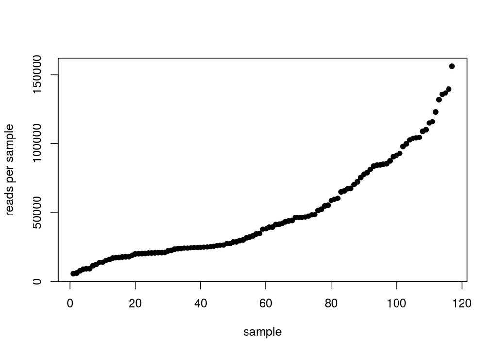

## 2.2) Normalization

Let’s normalize the original dataset by randomly subsampling 5836 reads in each station:

```r
library(vegan)
tb16_tax_occur_min5836_t<-t(tb16_tax_occur_min5836)
tb16_tax_occur_ss5836<-rrarefy(tb16_tax_occur_min5836_t, 5836)
```

The normalized table shows the following dimensions and format:

```
## [1] 117 960
```

```
##       OTU_1 OTU_2 OTU_3 OTU_4 OTU_5
## st001  4063   680     0    91    90
## st002  3473   954     1   214    87
## st003  4334   688     0    86    53
## st004  3881   706     3   155    84
## st005  4139   773     0   140   118
```

Its content fits with the expected normalization values (5836 reads per station):

```r
rowSums(tb16_tax_occur_ss5836)
```

```
## st001 st002 st003 st004 st005 st007 st009 st010 st012 st013 st014 st015
##  5836  5836  5836  5836  5836  5836  5836  5836  5836  5836  5836  5836
## st017 st018 st019 st022 st023 st024 st025 st026 st027 st028 st029 st030
##  5836  5836  5836  5836  5836  5836  5836  5836  5836  5836  5836  5836
## st032 st033 st034 st035 st037 st038 st039 st040 st041 st043 st044 st045
##  5836  5836  5836  5836  5836  5836  5836  5836  5836  5836  5836  5836
## st046 st047 st049 st050 st051 st052 st053 st055 st056 st057 st058 st059
##  5836  5836  5836  5836  5836  5836  5836  5836  5836  5836  5836  5836
## st060 st062 st063 st064 st065 st066 st067 st068 st069 st070 st071 st072
##  5836  5836  5836  5836  5836  5836  5836  5836  5836  5836  5836  5836
## st073 st074 st075 st076 st077 st078 st079 st081 st082 st083 st085 st086
##  5836  5836  5836  5836  5836  5836  5836  5836  5836  5836  5836  5836
## st087 st088 st089 st092 st093 st094 st095 st096 st097 st098 st101 st102
##  5836  5836  5836  5836  5836  5836  5836  5836  5836  5836  5836  5836
## st103 st104 st106 st107 st108 st109 st110 st112 st114 st115 st116 st118
##  5836  5836  5836  5836  5836  5836  5836  5836  5836  5836  5836  5836
## st119 st120 st121 st125 st126 st127 st128 st129 st130 st131 st132 st133
##  5836  5836  5836  5836  5836  5836  5836  5836  5836  5836  5836  5836
## st134 st135 st138 st139 st140 st141 st143 st145 st146
##  5836  5836  5836  5836  5836  5836  5836  5836  5836
```

Let’s check out how many OTUs don’t appear in the new table:

```r
length(which(colSums(tb16_tax_occur_ss5836)==0))
```

```
## [1] 39
```

```r
tb16_tax_occur_ss5836_no_cero<-tb16_tax_occur_ss5836[,-(which(colSums(tb16_tax_occur_ss5836)==0))]
dim(tb16_tax_occur_ss5836_no_cero)
```

```
## [1] 117 921
```

## 2.3) General community analysis

### 2.3.1) Richness and evenness (Shannon index)

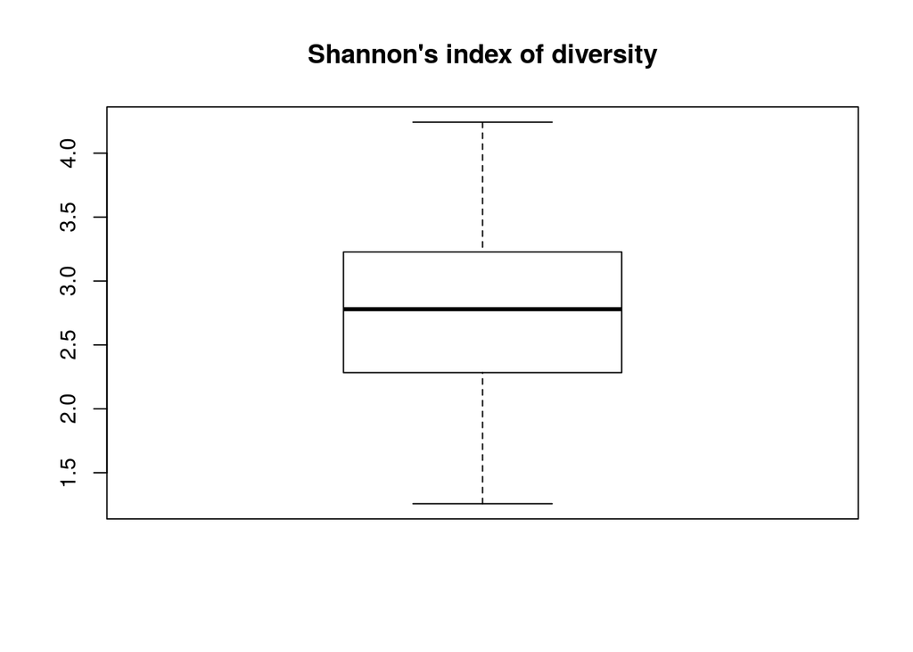

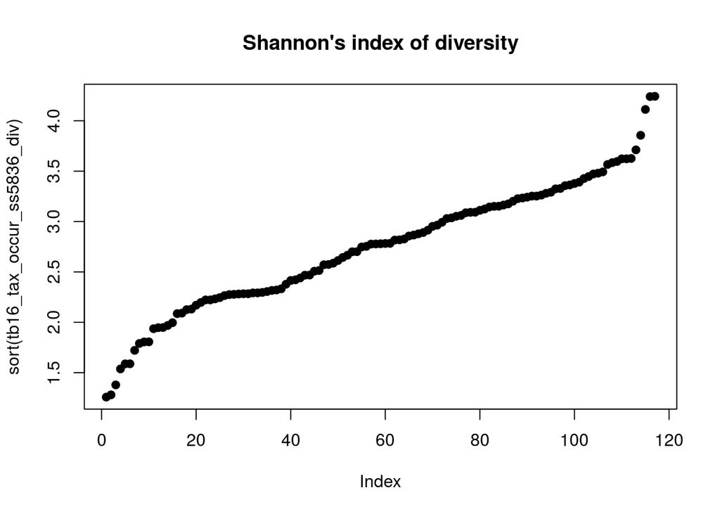

### 2.3.2) Richness: OTU number

Lowest number of OTUs per sample:

```
## [1] 136
```

Maximum number of OTUs per sample:

```
## [1] 356
```

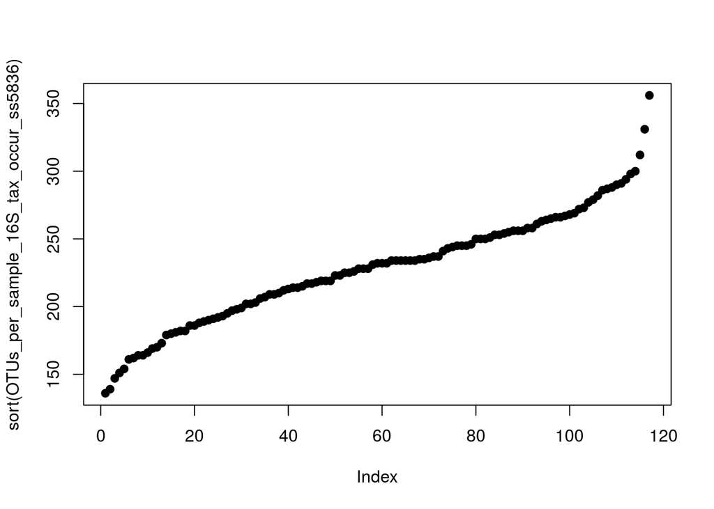

```r
plot(sort(OTUs_per_sample_16S_tax_occur_ss5836), pch=19)
```

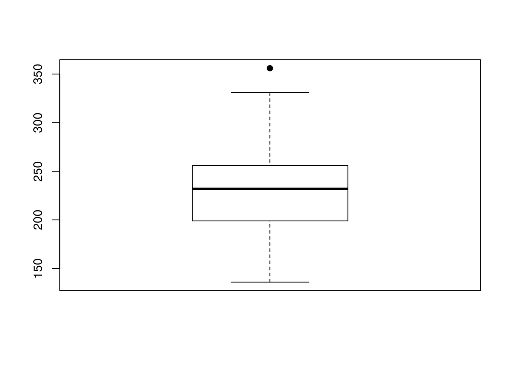

```r
boxplot(OTUs_per_sample_16S_tax_occur_ss5836, pch=19)
```